# Homework 5: Classification and its Multiclass Extension

Vijay Penmetsa

There are six questions (30 total points) in this assignment. The minimum increment is 1 point. Please type in your answers directly in the R Markdown file. After completion, **successfully** knitr it as an html file. Submit **both** the html file and the R Markdown file via Canvas. Please name the R Markdown file in the following format: LastName_FirstName_HW5.Rmd, e.g. Zhao_Zifeng_HW5.Rmd.

## Credit Default Dataset [18 points]

The credit default dataset contains information on ten thousand customers. The aim here is to predict which customers will default on their credit card debt. The data is stored in `Default.csv`. It contains 4 variables, `default`, `student`, `balance` and `income`. We would like to build several statistical models to predict the probability of `default` of a person with given personal information. The data description is as follows.

- `default`: A factor with levels No and Yes indicating whether the customer defaulted on their debt
- `student`: A factor with levels No and Yes indicating whether the customer is a student
- `balance`: The average balance that the customer has remaining on their credit card after making their monthly payment
- `income`: Income of customer

### **Q1 [6 points]** Data Partition and Exploration

**Q1(a) [2 points]** Let’s correctly read in the data in `Default.csv` and name it as `total_data`.

```r
## Write code solution to Q1(a) here
total_data <- read.csv("./Default.csv", header=T, stringsAsFactors=T)
```

**Q1(b) [2 points]** Among the 10000 customers in the dataset, how many of them default?

```r
## Write code solution to Q1(b) here
nrow(total_data[total_data$default == 'Yes', ])
```

```
## [1] 333
```

**Q1(c) [2 points]** Let’s partition the data in `total_data` into training **(60%)** and test data **(40%)** and store them as `R` objects `train_data` and `test_data` respectively. Use random seed **`set.seed(7)`**!

```r
## Write code solution to Q1(c) here
set.seed(7)

total_obs <- dim(total_data)[1]

train_data_indices <- sample(1:total_obs, 0.6*total_obs)
train_data <- total_data[train_data_indices,]
test_data <- total_data[-train_data_indices,]
```

### **Q2 [6 points]** Logistic Regression and GAM

**Q2(a) [2 points]** Fit a logistic regression model of `default` w.r.t. all 3 predictors using the **training data**, name it `lm_full`.

```r
## Write code solution to Q2(a) here
lm_full <- glm(default ~ student + balance + income,
               family = 'binomial', data = train_data)
```

```r
summary(lm_full)
```

```
##
## Call:
## glm(formula = default ~ student + balance + income, family = "binomial",
##     data = train_data)
##
## Deviance Residuals:
##     Min       1Q   Median       3Q      Max
## -2.4525  -0.1496  -0.0599  -0.0224   3.2929
##
## Coefficients:
##               Estimate Std. Error z value Pr(>|z|)
## (Intercept) -1.075e+01  6.204e-01 -17.330   <2e-16 ***
## studentYes  -4.645e-01  3.007e-01  -1.545    0.122
## balance      5.602e-03  2.871e-04  19.515   <2e-16 ***
## income       6.229e-06  1.040e-05   0.599    0.549
## ---
## Signif. codes:  0 '***' 0.001 '**' 0.01 '*' 0.05 '.' 0.1 ' ' 1
##
## (Dispersion parameter for binomial family taken to be 1)
##
##     Null deviance: 1820.57  on 5999  degrees of freedom
## Residual deviance:  996.23  on 5996  degrees of freedom
## AIC: 1004.2
##
## Number of Fisher Scoring iterations: 8
```

**Q2(b) [2 points]** Perform backward selection of `lm_full` via BIC and name the new model `lm_bwd`. Is any variable removed?

```r
## Write code solution to Q2(b) here
lm_bwd <- step(lm_full, direction = 'backward', k = log(dim(train_data)[1]))
```

```
## Start:  AIC=1031.03
## default ~ student + balance + income
##
##           Df Deviance    AIC
## - income   1   996.59 1022.7
## - student  1   998.60 1024.7
## <none>         996.23 1031.0
## - balance  1  1810.88 1837.0
##
## Step:  AIC=1022.69
## default ~ student + balance
##
##           Df Deviance    AIC
## <none>         996.59 1022.7
## - student  1  1007.98 1025.4
## - balance  1  1812.12 1829.5
```

‘income’ was the only variable removed by backward selection

**Q2(c) [2 points]** Fit a GAM of `default` w.r.t. all 3 predictors using the **training data**, name it `gam1`. Let’s use splines with **df=4** for the numerical predictors, which include `balance` and `income`.

```r
## Write code solution to Q2(c) here
library(gam)
gam1 <- gam(default ~ student + s(balance, df = 4) + s(income, df = 4),
               family = 'binomial', data = train_data)
```

```r
summary(gam1)
```

```
##
## Call: gam(formula = default ~ student + s(balance, df = 4) + s(income,
##     df = 4), family = "binomial", data = train_data)
## Deviance Residuals:
##       Min        1Q    Median        3Q       Max
## -2.096086 -0.149249 -0.040313 -0.008443  3.319502
##
## (Dispersion Parameter for binomial family taken to be 1)
##
##     Null Deviance: 1820.574 on 5999 degrees of freedom
## Residual Deviance: 986.0029 on 5990 degrees of freedom
## AIC: 1006.002
##
## Number of Local Scoring Iterations: NA
##
## Anova for Parametric Effects
##                      Df  Sum Sq Mean Sq  F value    Pr(>F)
## student               1    3.23    3.23   6.8671  0.008802 **
## s(balance, df = 4)    1  342.82  342.82 727.7876 < 2.2e-16 ***
## s(income, df = 4)     1    0.89    0.89   1.8896  0.169297
## Residuals          5990 2821.52    0.47
## ---
## Signif. codes:  0 '***' 0.001 '**' 0.01 '*' 0.05 '.' 0.1 ' ' 1
##
## Anova for Nonparametric Effects
##                    Npar Df Npar Chisq  P(Chi)
## (Intercept)
## student
## s(balance, df = 4)       3     6.5342 0.08833 .
## s(income, df = 4)        3     3.2630 0.35277
## ---
## Signif. codes:  0 '***' 0.001 '**' 0.01 '*' 0.05 '.' 0.1 ' ' 1
```

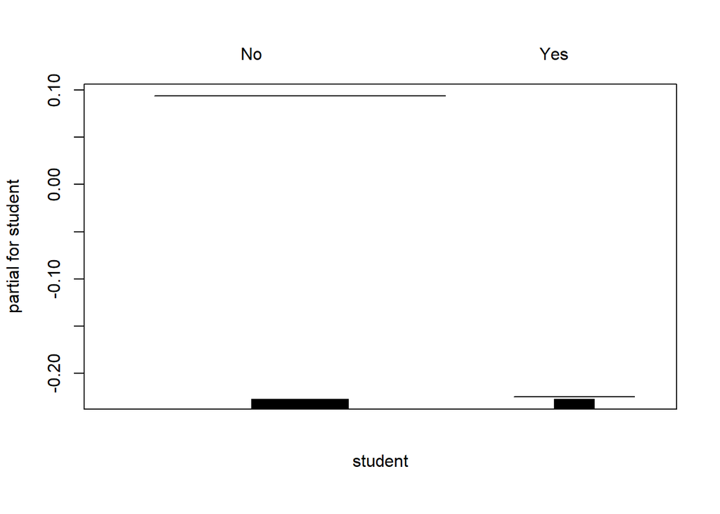

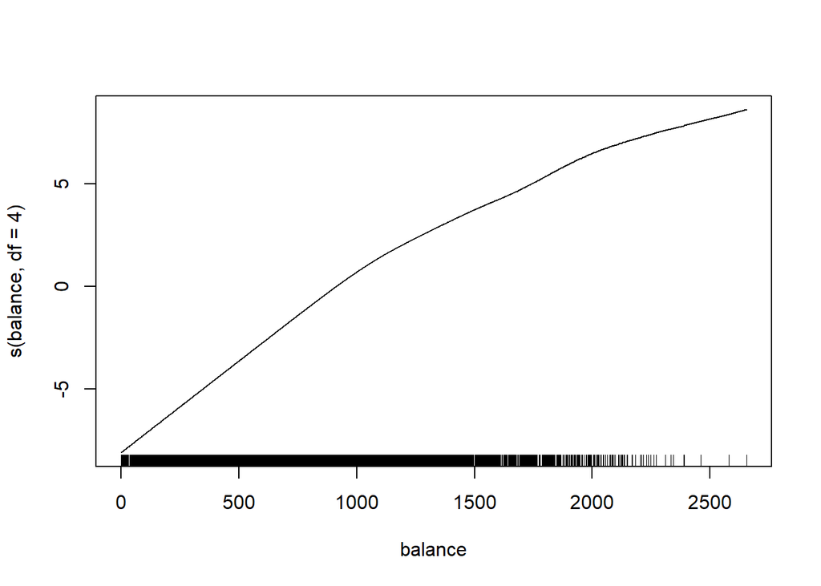

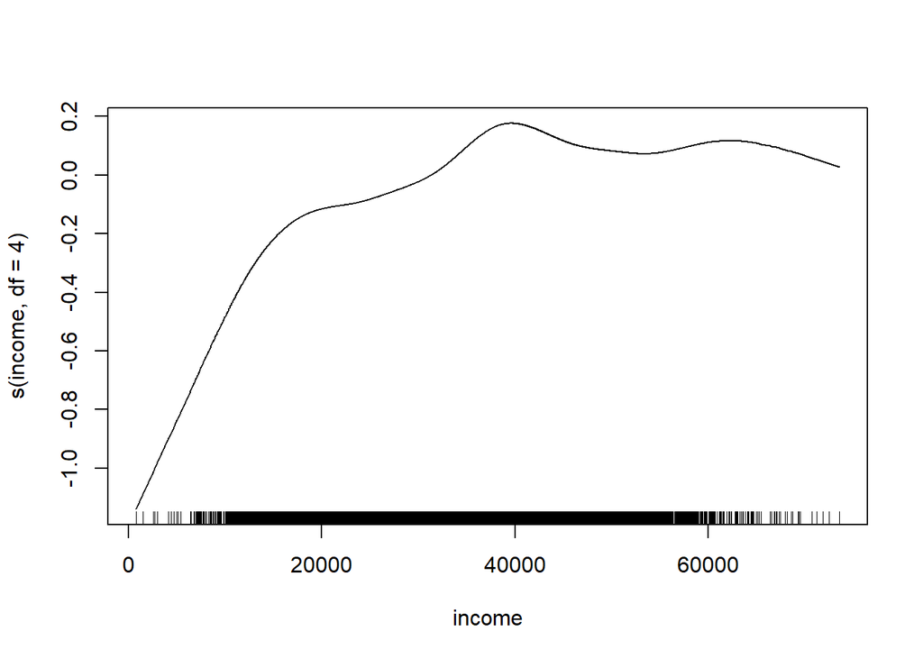

```r
plot(gam1)
```

### **Q3 [6 points]** Model Evaluation (Prediction)

**Q3(a) [2 points]** Use `lm_full` and `gam1` to generate probability predictions for `default` on the test data and store the predicted probability in `lm_full_pred` and `gam1_pred` respectively.

```r
## Write code solution to Q3(a) here
lm_full_pred <- predict(lm_full, newdata=test_data, type = 'response')
gam1_pred <- predict(gam1, newdata=test_data, type = 'response')
```

**Q3(b) [2 points]** Use the `confusionMatrix()` function in the `R` package `caret` to evaluate the prediction performance of `lm_full` and `gam1`. What are the sensitivity of `lm_full` and `gam1`?

```r
## Write code solution to Q3(b) here
library(caret)
lm_full_acc <- confusionMatrix(factor(ifelse(lm_full_pred>0.5, 'Yes', 'No')),
                               test_data$default,
                               positive = 'Yes')
gam1_acc <- confusionMatrix(factor(ifelse(gam1_pred>0.5, 'Yes', 'No')),
                            test_data$default,
                            positive = 'Yes')
```

```r
lm_full_acc
```

```
## Confusion Matrix and Statistics
##
##           Reference
## Prediction   No  Yes
##        No  3862   76
##        Yes   15   47
##
##                Accuracy : 0.9772
##                  95% CI : (0.9721, 0.9816)
##     No Information Rate : 0.9692
##     P-Value [Acc > NIR] : 0.001332
##
##                   Kappa : 0.4978
##
##  Mcnemar's Test P-Value : 3.181e-10
##
##             Sensitivity : 0.38211
##             Specificity : 0.99613
##          Pos Pred Value : 0.75806
##          Neg Pred Value : 0.98070
##              Prevalence : 0.03075
##          Detection Rate : 0.01175
##    Detection Prevalence : 0.01550
##       Balanced Accuracy : 0.68912
##
##        'Positive' Class : Yes
##
```

```r
gam1_acc
```

```
## Confusion Matrix and Statistics
##
##           Reference
## Prediction   No  Yes
##        No  3861   79
##        Yes   16   44
##
##                Accuracy : 0.9762
##                  95% CI : (0.971, 0.9807)
##     No Information Rate : 0.9692
##     P-Value [Acc > NIR] : 0.004603
##
##                   Kappa : 0.4702
##
##  Mcnemar's Test P-Value : 2.004e-10
##
##             Sensitivity : 0.35772
##             Specificity : 0.99587
##          Pos Pred Value : 0.73333
##          Neg Pred Value : 0.97995
##              Prevalence : 0.03075
##          Detection Rate : 0.01100
##    Detection Prevalence : 0.01500
##       Balanced Accuracy : 0.67680
##
##        'Positive' Class : Yes
##
```

lm_full sensitivity = 0.38211 gam1 sensitivity = 0.35772

**Q3(c) [2 points]** Note that the sensitivity of `lm_full` and `gam1` are in the range of 30-40%, which means that the models are having a hard time finding the customers that default. This is not surprising considering that most customers do NOT default. One way to improve sensitivity is to use a threshold **lower** than **0.5** to classify the customer. Let’s use a new threshold **0.1**, i.e. we think a customer will default if the predicted probability of default > 0.1.

Use **0.1** as the new classification threshold and calculate the sensitivity for `lm_full` and `gam1`. Did the sensitivity go up? What is the price we need to pay for increasing sensitivity?

```r
## Write code solution to Q3(c) here
lm_full_acc_1 <- confusionMatrix(factor(ifelse(lm_full_pred>0.1, 'Yes', 'No')),
                               test_data$default,
                               positive = 'Yes')
gam1_acc_1 <- confusionMatrix(factor(ifelse(gam1_pred>0.1, 'Yes', 'No')),
                            test_data$default,
                            positive = 'Yes')
```

```r
lm_full_acc_1
```

```
## Confusion Matrix and Statistics
##
##           Reference
## Prediction   No  Yes
##        No  3636   28
##        Yes  241   95
##
##                Accuracy : 0.9328
##                  95% CI : (0.9245, 0.9403)
##     No Information Rate : 0.9692
##     P-Value [Acc > NIR] : 1
##
##                   Kappa : 0.3863
##
##  Mcnemar's Test P-Value : <2e-16
##
##             Sensitivity : 0.77236
##             Specificity : 0.93784
##          Pos Pred Value : 0.28274
##          Neg Pred Value : 0.99236
##              Prevalence : 0.03075
##          Detection Rate : 0.02375
##    Detection Prevalence : 0.08400
##       Balanced Accuracy : 0.85510
##
##        'Positive' Class : Yes
##
```

```r
gam1_acc_1
```

```
## Confusion Matrix and Statistics
##
##           Reference
## Prediction   No  Yes
##        No  3621   28
##        Yes  256   95
##
##                Accuracy : 0.929
##                  95% CI : (0.9206, 0.9368)
##     No Information Rate : 0.9692
##     P-Value [Acc > NIR] : 1
##
##                   Kappa : 0.3723
##
##  Mcnemar's Test P-Value : <2e-16
##
##             Sensitivity : 0.77236
##             Specificity : 0.93397
##          Pos Pred Value : 0.27066
##          Neg Pred Value : 0.99233
##              Prevalence : 0.03075
##          Detection Rate : 0.02375
##    Detection Prevalence : 0.08775
##       Balanced Accuracy : 0.85316
##
##        'Positive' Class : Yes
##
```

Changes

```r
#Changes to Accuracy
lm_full_acc_1$overall['Accuracy'] - lm_full_acc$overall['Accuracy']
```

```
## Accuracy
##  -0.0445
```

```r
gam1_acc_1$overall['Accuracy'] - gam1_acc$overall['Accuracy']
```

```
## Accuracy
## -0.04725
```

```r
#Changes to Sensitivity
lm_full_acc_1$byClass['Sensitivity'] - lm_full_acc$byClass['Sensitivity']
```

```
## Sensitivity
##   0.3902439
```

```r
gam1_acc_1$byClass['Sensitivity'] - gam1_acc$byClass['Sensitivity']
```

```
## Sensitivity
##   0.4146341
```

```r
#Changes to Specificity
lm_full_acc_1$byClass['Specificity'] - lm_full_acc$byClass['Specificity']
```

```
## Specificity
## -0.05829249
```

```r
gam1_acc_1$byClass['Specificity'] - gam1_acc$byClass['Specificity']
```

```
## Specificity
## -0.06190353
```

Sensitivity for both the models have gone up but it as negatively affected the prediction accuracy and specificity. Both accuracy and specificity have gone down when threshold was changed from 0.5 to 0.1 for both the models.

## Iris Dataset [12 points]

The famous R.A. Fisher’s iris dataset contains the measurements (in centimeters) of the variables sepal length and width and petal length and width, respectively, for 50 flowers from each of 3 species of iris. The species are Iris `setosa`, `versicolor`, and `virginica`.

The data is distributed with `R`. It contains 5 variables, `Sepal.Length`, `Sepal.Width`, `Petal.Length`, `Petal.Width` and `Species`. We would like to build several statistical models to classify the species of a given iris based on its sepal length and width and petal length and width. The data description is as follows.

- `Sepal.Length`: sepal length
- `Sepal.Width`: sepal width
- `Petal.Length`: petal length
- `Petal.Width`: petal width
- `Species`: species

We first read in the data and use the `createDataPartition()` function in the `R` package `caret` to partition the data in `total_data` into training **(50%)** and test data **(50%)** and store them as `R` objects `train_data` and `test_data` respectively.

```r
library(caret)
total_data <- iris
set.seed(7)
train_index <- createDataPartition(total_data$Species, p=0.5, list=F)
train_data <- total_data[train_index,]
test_data <- total_data[-train_index,]
```

### **Q4 [2 points]** Multinomial Logistic Regression

Fit a multinomial logistic regression model of `Species` w.r.t. all 4 predictors using the **training data**, name it `lm1`.

```r
## Write code solution to Q4 here
library(nnet)
lm1 <- multinom(Species~Sepal.Length+Sepal.Width+Petal.Length+Petal.Width,
                data = train_data)
summary(lm1)
```

```
## Call:
## multinom(formula = Species ~ Sepal.Length + Sepal.Width + Petal.Length +
##     Petal.Width, data = train_data)
##
## Coefficients:
##            (Intercept) Sepal.Length Sepal.Width Petal.Length Petal.Width
## versicolor    189.4474    -56.24596   -21.76972     83.12229   -45.55289
## virginica    -193.6000    -28.26128   -69.84021     98.04740   117.65365
##
## Std. Errors:
##            (Intercept) Sepal.Length Sepal.Width Petal.Length Petal.Width
## versicolor    5934.361     2435.832    1308.241     847.2404    349.3882
## virginica     6106.952     2274.299    1224.006     726.3655    316.1417
##
## Residual Deviance: 0.00938211
## AIC: 20.00938
```

### **Q5 [4 points]** Multiclass Neural Networks

Fit an NN model of `Species` w.r.t. all 4 predictors using the **training data**, name it `nn1`. For the architecture of NN, let’s use one hidden layer with 4 hidden units.

**Q5(a) [2 points]** Let’s generate the **training dataset** that are needed for the estimation of NN using the function `model.matrix()` and store it in `x_train_nn`. In addition, use the `scale()` function to standardize the predictors by centering with mean and scaling with sd. Let’s further combine the dependent variable `Species` with the standardized predictors `x_train_nn` generated. Let’s further generate the **test dataset** that are needed for the out-of-sample prediction evaluation of NN using the function `model.matrix` and store it in `x_test_nn`. Use the `scale()` function to standardize the predictors by centering with mean and scaling with sd.

```r
## Write code solution to Q5(a) here
x_train_nn <- model.matrix(~Sepal.Length+Sepal.Width+Petal.Length+Petal.Width,
                           data=train_data)[,-1]

x_mean <- apply(x_train_nn, 2, mean)
x_sd <- apply(x_train_nn, 2, sd)

x_train_nn <- scale(x_train_nn, center=x_mean, scale=x_sd)
x_train_nn <- cbind.data.frame(train_data$Species, x_train_nn)
colnames(x_train_nn)[1] <- 'Species'

x_test_nn <- model.matrix(~Sepal.Length+Sepal.Width+Petal.Length+Petal.Width,
                          data=test_data)[,-1]
x_test_nn <- scale(x_test_nn, center=x_mean, scale=x_sd)
```

**Q5(b) [2 points]** Let’s fit an NN that has one hidden layer with 4 hidden units and name it `nn1`. Make sure to use random seed **`set.seed(7)`**!

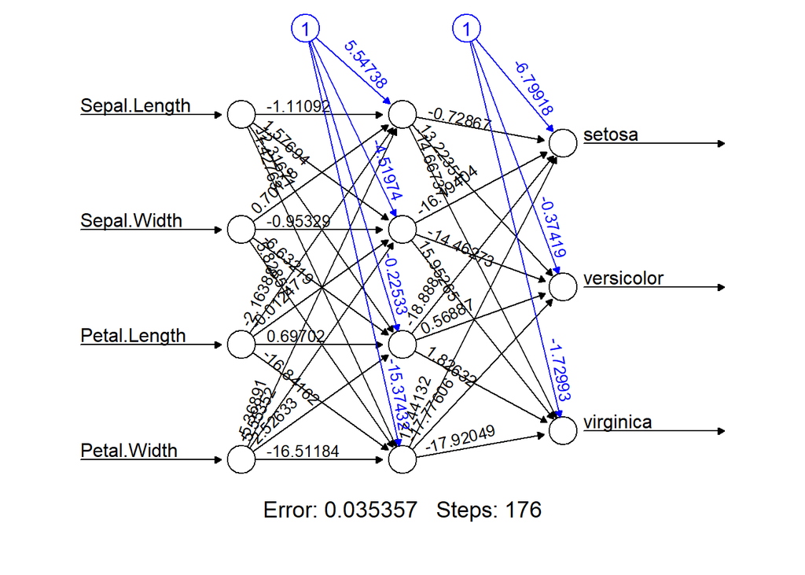

```r
## Write code solution to Q5(b) here
library(neuralnet)
set.seed(7)
nn1 <- neuralnet(Species~Sepal.Length+Sepal.Width+Petal.Length+Petal.Width,
                 data=x_train_nn, linear.output=F, hidden=c(4))

plot(nn1, rep = 'best')
```

### **Q6 [6 points]** Model Evaluation (Prediction)

**Q6(a) [2 points]** Use `lm1` and `nn1` to generate probability predictions for `Species` on the test data and store the predicted probability in `lm1_pred` and `nn1_pred` respectively.

```r
## Write code solution to Q6(a) here
lm1_pred <- predict(lm1, newdata=test_data, type = 'probs')
nn1_pred <- predict(nn1, newdata=x_test_nn, type = 'probs')
```

**Q6(b) [2 points]** Use the `confusionMatrix()` function in the `R` package `caret` to evaluate the prediction performance of `lm1` and `nn1`.

```r
## Write code solution to Q6(b) here
library(caret)
class_labels <- levels(train_data$Species)

lm1_pred_class <- factor(class_labels[apply(lm1_pred, 1, which.max)])
lm1_acc <- confusionMatrix(lm1_pred_class, reference=test_data$Species)

nn1_pred_class <- factor(class_labels[apply(nn1_pred, 1, which.max)])
nn1_acc <- confusionMatrix(nn1_pred_class, reference=test_data$Species)
```

```r
lm1_acc
```

```
## Confusion Matrix and Statistics
##
##             Reference
## Prediction   setosa versicolor virginica
##   setosa         25          0         0
##   versicolor      0         24         4
##   virginica       0          1        21
##
## Overall Statistics
##
##                Accuracy : 0.9333
##                  95% CI : (0.8512, 0.978)
##     No Information Rate : 0.3333
##     P-Value [Acc > NIR] : < 2.2e-16
##
##                   Kappa : 0.9
##
##  Mcnemar's Test P-Value : NA
##
## Statistics by Class:
##
##                      Class: setosa Class: versicolor Class: virginica
## Sensitivity                 1.0000            0.9600           0.8400
## Specificity                 1.0000            0.9200           0.9800
## Pos Pred Value              1.0000            0.8571           0.9545
## Neg Pred Value              1.0000            0.9787           0.9245
## Prevalence                  0.3333            0.3333           0.3333
## Detection Rate              0.3333            0.3200           0.2800
## Detection Prevalence        0.3333            0.3733           0.2933
## Balanced Accuracy           1.0000            0.9400           0.9100
```

```r
nn1_acc
```

```
## Confusion Matrix and Statistics
##
##             Reference
## Prediction   setosa versicolor virginica
##   setosa         25          0         0
##   versicolor      0         24         4
##   virginica       0          1        21
##
## Overall Statistics
##
##                Accuracy : 0.9333
##                  95% CI : (0.8512, 0.978)
##     No Information Rate : 0.3333
##     P-Value [Acc > NIR] : < 2.2e-16
##
##                   Kappa : 0.9
##
##  Mcnemar's Test P-Value : NA
##
## Statistics by Class:
##
##                      Class: setosa Class: versicolor Class: virginica
## Sensitivity                 1.0000            0.9600           0.8400
## Specificity                 1.0000            0.9200           0.9800
## Pos Pred Value              1.0000            0.8571           0.9545
## Neg Pred Value              1.0000            0.9787           0.9245
## Prevalence                  0.3333            0.3333           0.3333
## Detection Rate              0.3333            0.3200           0.2800
## Detection Prevalence        0.3333            0.3733           0.2933
## Balanced Accuracy           1.0000            0.9400           0.9100
```

**Q6(c) [2 points]** Which statistical model do you prefer, `lm1` or `nn1`? Give reasons.

Answer: I prefer lm1. Both the models have the same accuracy, sensitivity and specificity, so lm1 is the better model due to its simplicity.